# R Notebook

```r
library(tidyverse)
library(janitor)
library(infer)
data(msleep)
```

Now check a few things about the dataset

```r
glimpse(msleep)
```

```
Observations: 83
Variables: 11
$ name         <chr> "Cheetah", "Owl monkey", "Mountain beaver", "Greater short-tailed…
$ genus        <chr> "Acinonyx", "Aotus", "Aplodontia", "Blarina", "Bos", "Bradypus", …
$ vore         <chr> "carni", "omni", "herbi", "omni", "herbi", "herbi", "carni", NA, …
$ order        <chr> "Carnivora", "Primates", "Rodentia", "Soricomorpha", "Artiodactyl…
$ conservation <chr> "lc", NA, "nt", "lc", "domesticated", NA, "vu", NA, "domesticated…
$ sleep_total  <dbl> 12.1, 17.0, 14.4, 14.9, 4.0, 14.4, 8.7, 7.0, 10.1, 3.0, 5.3, 9.4,…
$ sleep_rem    <dbl> NA, 1.8, 2.4, 2.3, 0.7, 2.2, 1.4, NA, 2.9, NA, 0.6, 0.8, 0.7, 1.5…
$ sleep_cycle  <dbl> NA, NA, NA, 0.1333333, 0.6666667, 0.7666667, 0.3833333, NA, 0.333…
$ awake        <dbl> 11.9, 7.0, 9.6, 9.1, 20.0, 9.6, 15.3, 17.0, 13.9, 21.0, 18.7, 14.…
$ brainwt      <dbl> NA, 0.01550, NA, 0.00029, 0.42300, NA, NA, NA, 0.07000, 0.09820, …
$ bodywt       <dbl> 50.000, 0.480, 1.350, 0.019, 600.000, 3.850, 20.490, 0.045, 14.00…
```

```r
names(msleep)
```

```
 [1] "name"         "genus"        "vore"         "order"        "conservation"
 [6] "sleep_total"  "sleep_rem"    "sleep_cycle"  "awake"        "brainwt"
[11] "bodywt"
```

```r
head(msleep)
```

| name | genus | vore | order | conservation | sleep_total | sleep_rem | sleep_cycle | awake | brainwt | bodywt |
| --- | --- | --- | --- | --- | --- | --- | --- | --- | --- | --- |
| Cheetah | Acinonyx | carni | Carnivora | lc | 12.1 | NA | NA | 11.9 | NA | 50.000 |
| Owl monkey | Aotus | omni | Primates | NA | 17.0 | 1.8 | NA | 7.0 | 0.01550 | 0.480 |
| Mountain beaver | Aplodontia | herbi | Rodentia | nt | 14.4 | 2.4 | NA | 9.6 | NA | 1.350 |
| Greater short-tailed shrew | Blarina | omni | Soricomorpha | lc | 14.9 | 2.3 | 0.1333333 | 9.1 | 0.00029 | 0.019 |
| Cow | Bos | herbi | Artiodactyla | domesticated | 4.0 | 0.7 | 0.6666667 | 20.0 | 0.42300 | 600.000 |
| Three-toed sloth | Bradypus | herbi | Pilosa | NA | 14.4 | 2.2 | 0.7666667 | 9.6 | NA | 3.850 |

So we have a long data frame.

Jabberwockies sleep for around 7 hours a night, on average. Perform an appropriate statistical test to determine whether the mean sleep_total in the sampled population of animal types differs from the typical value for jabberwockies.

```r
ave_sleep <- msleep %>%
  summarise(mean_sleep = mean(sleep_total))
ave_sleep
```

| mean_sleep |
| --- |
| 10.43373 |

#Average sleep is clearly more than 7 hours a night, assuming the unit of sleep_total is hours.

Ho : avearge rating = 7 Ha : average rating != 7

```r
null_distribution <- msleep %>%
  specify(response = sleep_total) %>%
  hypothesize(null = "point", mu = 7) %>%
  generate(reps = 10000, type = "bootstrap") %>%
  calculate(stat = "mean")
```

Now lets work out the observed statistic, the mean total sleep of animals

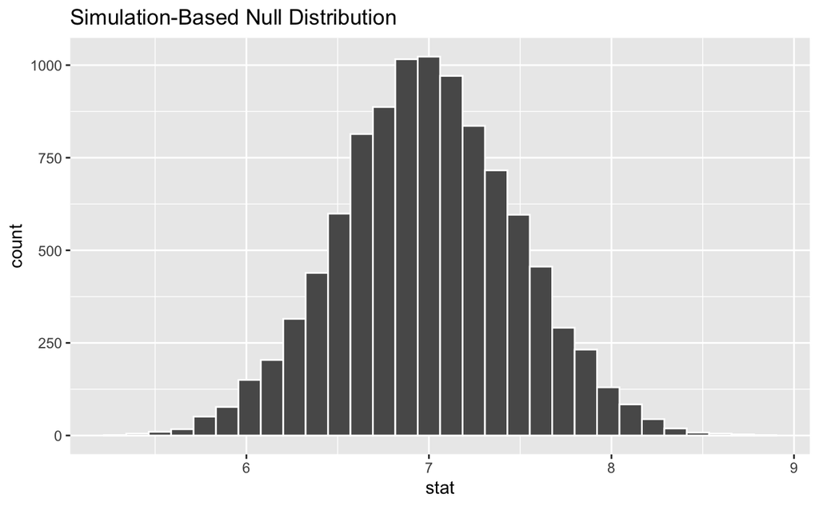

```r
null_distribution %>%
  visualise(bins = 30)
```

```r
shade_p_value(obs_stat = ave_sleep$mean_sleep, direction = "both")
```

[output not shown]

Finally get the p-value

```r
p_value <- null_distribution %>%
  get_p_value(obs_stat = ave_sleep, direction = "both")
```

```
Please be cautious in reporting a p-value of 0. This result is an approximation based on the number of `reps` chosen in the `generate()` step. See `?get_p_value()` for more information.
```

```r
p_value
```

| p_value |
| --- |
| 0 |

P value is zero, which we’d expect as mean_sleep already worked out to be greater than 10 so the mean sleep total differs in the sample population significantly.

Perform an appropriate statistical test to determine whether omnivores sleep for significantly longer than herbivores, on average. Note there are some NA values, we need to remove these

```r
no_na_vore <- msleep %>%
  filter(!is.na(vore)) %>%
  glimpse()
```

```
Observations: 76
Variables: 11
$ name         <chr> "Cheetah", "Owl monkey", "Mountain beaver", "Greater short-tailed…
$ genus        <chr> "Acinonyx", "Aotus", "Aplodontia", "Blarina", "Bos", "Bradypus", …
$ vore         <chr> "carni", "omni", "herbi", "omni", "herbi", "herbi", "carni", "car…
$ order        <chr> "Carnivora", "Primates", "Rodentia", "Soricomorpha", "Artiodactyl…
$ conservation <chr> "lc", NA, "nt", "lc", "domesticated", NA, "vu", "domesticated", "…
$ sleep_total  <dbl> 12.1, 17.0, 14.4, 14.9, 4.0, 14.4, 8.7, 10.1, 3.0, 5.3, 9.4, 10.0…
$ sleep_rem    <dbl> NA, 1.8, 2.4, 2.3, 0.7, 2.2, 1.4, 2.9, NA, 0.6, 0.8, 0.7, 1.5, 2.…
$ sleep_cycle  <dbl> NA, NA, NA, 0.1333333, 0.6666667, 0.7666667, 0.3833333, 0.3333333…
$ awake        <dbl> 11.9, 7.0, 9.6, 9.1, 20.0, 9.6, 15.3, 13.9, 21.0, 18.7, 14.6, 14.…
$ brainwt      <dbl> NA, 0.01550, NA, 0.00029, 0.42300, NA, NA, 0.07000, 0.09820, 0.11…
$ bodywt       <dbl> 50.000, 0.480, 1.350, 0.019, 600.000, 3.850, 20.490, 14.000, 14.8…
```

Find prop for omnivores

```r
prop_omni <- no_na_vore %>%
  group_by(vore) %>%
  summarise(prop = n()/nrow(no_na_vore)) %>%
  filter(vore == "omni")
prop_omni
```

| vore | prop |
| --- | --- |
| omni | 0.2631579 |

Find prop for herbivores

```r
prop_herbi <- no_na_vore %>%
  group_by(vore) %>%
  summarise(prop = n()/nrow(no_na_vore)) %>%
  filter(vore == "herbi")
prop_herbi
```

| vore | prop |
| --- | --- |
| herbi | 0.4210526 |

Say alpha = 0.05 and H0 : mu_sleep_herbi -mu_sleep_omni = 0 Ha : mu_sleep_herbi -mu_sleep_omni != 0

```r
sleep_diff <- no_na_vore %>%
  select(sleep_total, vore)
head(sleep_diff)
```

| sleep_total | vore |
| --- | --- |
| 12.1 | carni |
| 17.0 | omni |
| 14.4 | herbi |
| 14.9 | omni |
| 4.0 | herbi |
| 14.4 | herbi |

```r
sleep_diff_herbi <- sleep_diff %>%
  group_by(vore) %>%
filter(vore == "herbi") %>%
  summarise(n = n())
sleep_diff_herbi
```

| vore | n |
| --- | --- |
| herbi | 32 |

```r
sleep_diff_omni <- sleep_diff %>%
  group_by(vore) %>%
filter(vore == "omni") %>%
  summarise(n = n())
sleep_diff_omni
```

| vore | n |
| --- | --- |
| omni | 20 |

```r
null_distribution <- sleep_diff %>%
  specify(sleep_total ~ vore) %>% #it is the relationship between sleep and vore we are testing. This can also be written like specify(response = sleep_total, explanatory = vore)
  hypothesize(null = "independence") %>% #the null hypothesis is there is no relationship i.e. they are independent
  generate(reps = 1000, type = "permute") %>%
  calculate(stat = "diff in means", order = c("herbi", "omni")) #our sample stat is mean of herbi minus mean of omni so this is the order we specify in the calculate step

head(null_distribution)
```

[output not shown]

#I need to create a mutate column somewhere to subtract omni form herbi, however this is generating errors

Perform an appropriate statistical test to determine whether the proportion of domesticated animal types in the population of animal types is greater than 5%.

```r
cons_tidy <- msleep %>%
  clean_names() %>%
  filter(!is.na(conservation)) %>%
  glimpse()
```

```
Observations: 54
Variables: 11
$ name         <chr> "Cheetah", "Mountain beaver", "Greater short-tailed shrew", "Cow…
$ genus        <chr> "Acinonyx", "Aplodontia", "Blarina", "Bos", "Callorhinus", "Cani…
$ vore         <chr> "carni", "herbi", "omni", "herbi", "carni", "carni", "herbi", "h…
$ order        <chr> "Carnivora", "Rodentia", "Soricomorpha", "Artiodactyla", "Carniv…
$ conservation <chr> "lc", "nt", "lc", "domesticated", "vu", "domesticated", "lc", "l…
$ sleep_total  <dbl> 12.1, 14.4, 14.9, 4.0, 8.7, 10.1, 3.0, 5.3, 9.4, 10.0, 12.5, 10.…
$ sleep_rem    <dbl> NA, 2.4, 2.3, 0.7, 1.4, 2.9, NA, 0.6, 0.8, 0.7, 1.5, 2.2, 1.4, 3…
$ sleep_cycle  <dbl> NA, NA, 0.1333333, 0.6666667, 0.3833333, 0.3333333, NA, NA, 0.21…
$ awake        <dbl> 11.90, 9.60, 9.10, 20.00, 15.30, 13.90, 21.00, 18.70, 14.60, 14.…
$ brainwt      <dbl> NA, NA, 0.00029, 0.42300, NA, 0.07000, 0.09820, 0.11500, 0.00550…
$ bodywt       <dbl> 50.000, 1.350, 0.019, 600.000, 20.490, 14.000, 14.800, 33.500, 0…
```

```r
cons_tidy %>%
  group_by(conservation) %>%
  summarise(prop = n()/nrow(cons_tidy)) %>%
  filter(conservation == "domesticated")
```

| conservation | prop |
| --- | --- |
| domesticated | 0.1851852 |

```r
cons_tidy_prop <- cons_tidy %>%
  mutate(is_domesticated = ifelse(conservation == "domesticated", "placid", "feral"))

head(cons_tidy_prop)
```

| name | genus | vore | order | conservation | sleep_total | sleep_rem | sleep_cycle | awake | brainwt | bodywt | is_domesticated |
| --- | --- | --- | --- | --- | --- | --- | --- | --- | --- | --- | --- |
| Cheetah | Acinonyx | carni | Carnivora | lc | 12.1 | NA | NA | 11.9 | NA | 50.000 | feral |
| Mountain beaver | Aplodontia | herbi | Rodentia | nt | 14.4 | 2.4 | NA | 9.6 | NA | 1.350 | feral |
| Greater short-tailed shrew | Blarina | omni | Soricomorpha | lc | 14.9 | 2.3 | 0.1333333 | 9.1 | 0.00029 | 0.019 | feral |
| Cow | Bos | herbi | Artiodactyla | domesticated | 4.0 | 0.7 | 0.6666667 | 20.0 | 0.42300 | 600.000 | placid |
| Northern fur seal | Callorhinus | carni | Carnivora | vu | 8.7 | 1.4 | 0.3833333 | 15.3 | NA | 20.490 | feral |
| Dog | Canis | carni | Carnivora | domesticated | 10.1 | 2.9 | 0.3333333 | 13.9 | 0.07000 | 14.000 | placid |

```r
null_distribution <- cons_tidy_prop %>%
  specify(response = is_domesticated, success = "placid") %>%
  hypothesize(null = "point", p = 0.05) %>%
  generate(reps = 5000, type = "simulate") %>%
  calculate(stat = "prop") #we specify that the stat is proportion (in the last lesson it was mean)

head(null_distribution)
```

| replicate | stat |
| --- | --- |
| 1 | 0.01851852 |
| 2 | 0.03703704 |
| 3 | 0.07407407 |
| 4 | 0.01851852 |
| 5 | 0.05555556 |
| 6 | 0.03703704 |

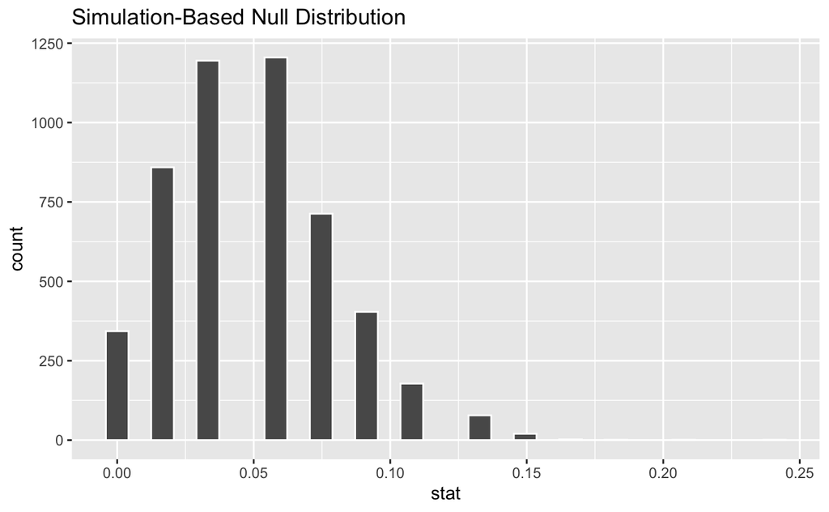

```r
null_distribution %>%
  visualise(bins = 30)
```

```r
observed_stat <- cons_tidy_prop %>%
  specify(response = is_domesticated, success = "placid") %>%
  calculate(stat = "prop")

observed_stat
```

| stat |
| --- |
| 0.1851852 |

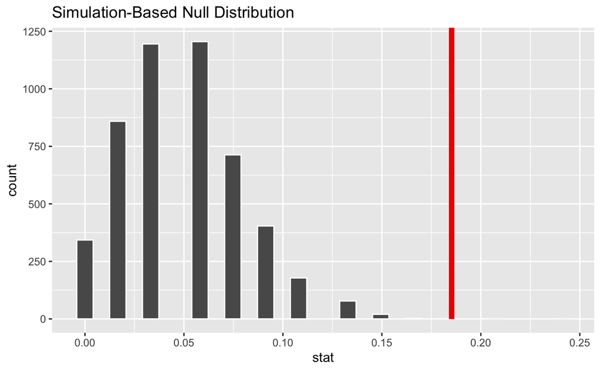

```r
null_distribution %>%
  visualise(bins = 30) + #remembering that it is a '+' here not '%>%' because using ggplot functionality to visualise
  shade_p_value(obs_stat = observed_stat, direction = "right")
```

```r
p_value <- null_distribution %>%
  get_p_value(obs_stat = observed_stat, direction = "right")

p_value
```

| p_value |
| --- |
| 6e-04 |

Answer = The proportion of animal types is statistically significantly higher than 5%